# Time Series Analysis: US Business Applications

James Beeson

# Overview

This short brief looks at weekly new business applications in the U.S. and what we learn by separating the data into trend and seasonal patterns using decomposition. The data come from the U.S. Census Bureau series “Business Applications” via FRED and are adjusted to thousands of applications per week. We focus on:

- What the overall pattern (trend) looks like
- Regular ups and downs within a year (seasonality)
- A clearer, seasonally adjusted view for interpretation

Source: [FRED – BUSAPPWNSAUS](https://fred.stlouisfed.org/series/BUSAPPWNSAUS)

**Plot**

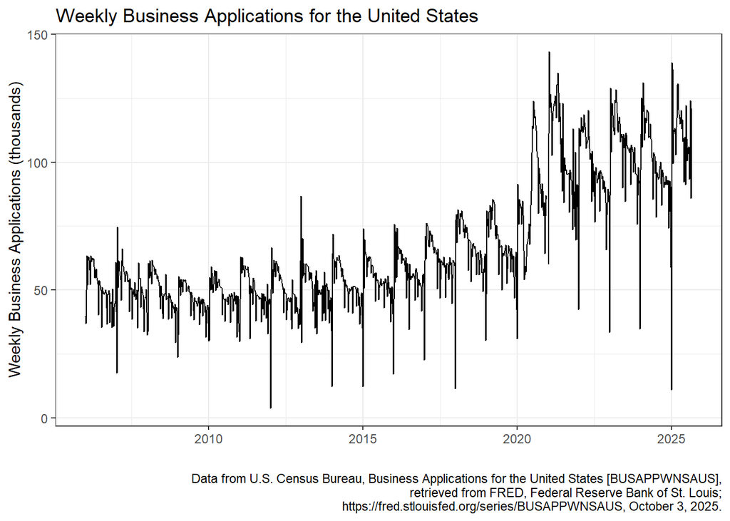

```r
pacman::p_load(
  tidyverse,
  tsibble,
  feasts,
  DT,
  zoo
)

app <- read_csv("BUSAPPWNSAUS.csv") %>% as_tsibble() %>%
  rename(date = observation_date, value = BUSAPPWNSAUS) %>%
  mutate(value = value/1000)

this_theme <- list(theme_bw(),
  labs(
    title = "Weekly Business Applications for the United States",
    y = "Weekly Business Applications (thousands)",
    x = "",
    caption = "Data from U.S. Census Bureau, Business Applications for the United States [BUSAPPWNSAUS],\nretrieved from FRED, Federal Reserve Bank of St. Louis;\nhttps://fred.stlouisfed.org/series/BUSAPPWNSAUS, October 3, 2025."
  ))

app %>% autoplot() + this_theme
```

**Table**

```r
DT::datatable(app)
```

|  | date | value |
| --- | --- | --- |
| 1 | 2006-01-07 | 39.58 |
| 2 | 2006-01-14 | 36.92 |
| 3 | 2006-01-21 | 63.3 |
| 4 | 2006-01-28 | 51.91 |
| 5 | 2006-02-04 | 61.43 |
| 6 | 2006-02-11 | 62.89 |
| 7 | 2006-02-18 | 61.79 |
| 8 | 2006-02-25 | 57.91 |
| 9 | 2006-03-04 | 52.08 |
| 10 | 2006-03-11 | 63.44 |

[output cut: 1016 more lines]

# Method

We clean the series for small gaps (linearly filling missing values) and then use a standard decomposition to split the data into:

- Trend: the longer-run direction of the series
- Seasonality: regular within-year patterns (we use a 52-week cycle)
- Remainder: the leftover week-to-week noise

This helps us remove seasonality to see the underlying movement more clearly.

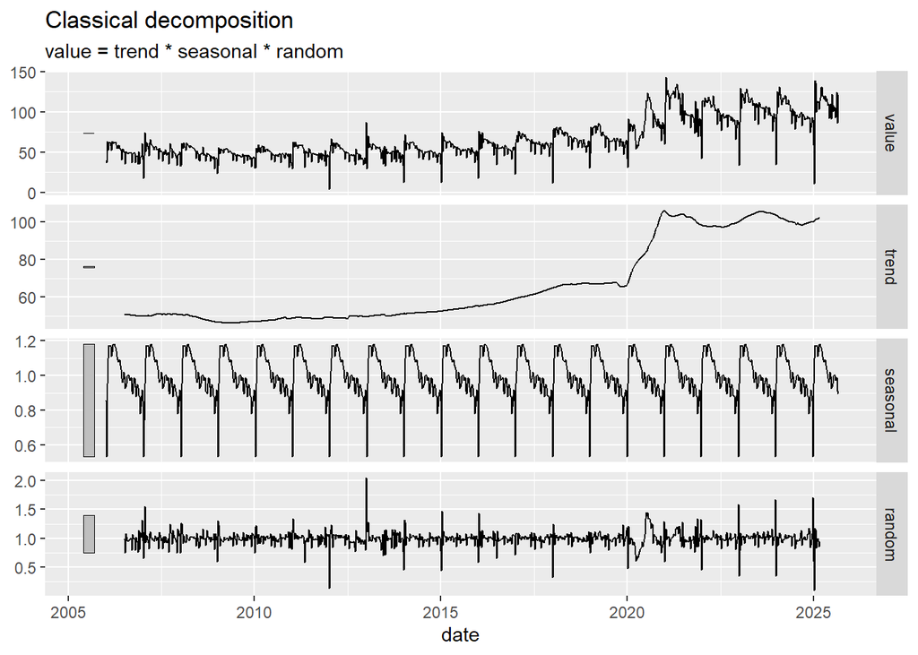

```r
app <- app %>%
  mutate(
    value = zoo::na.approx(value) # in 'zoo' package
  )

decomp <- app %>%
    model(feasts::classical_decomposition(value ~ season(52),
        type = "mult")) %>%
    components()

autoplot(decomp)
```

# Insights

### Seasonality

- Common dips occur around major holidays when filings slow down
- A noticeable spike appears at the start of the year
- The seasonal pattern is fairly consistent across years

To illustrate this, the plot below shows the seasonal component for the series with vertical lines at major U.S. holidays.

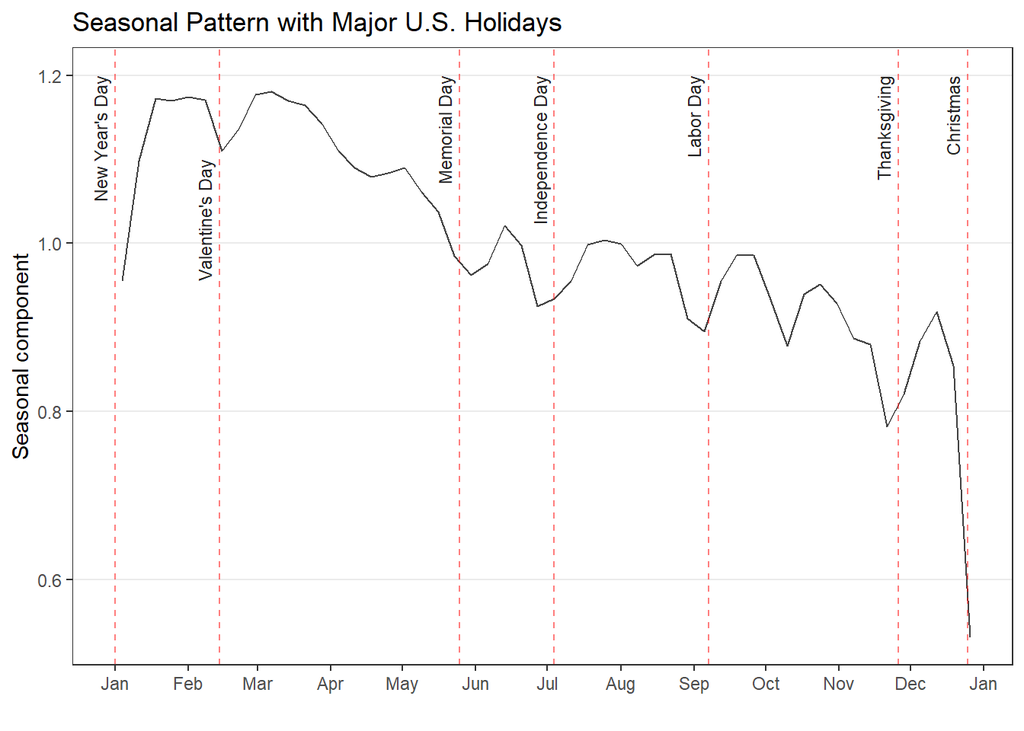

```r
seasonal <- decomp %>% filter(lubridate::year(date) == 2020)

holidays <- tibble::tibble(
  name = c(
    "New Year\'s Day", "Valentine\'s Day", "Memorial Day", "Independence Day",
    "Labor Day", "Thanksgiving", "Christmas"
  ),
  date = as.Date(c(
    "2020-01-01", "2020-02-14", "2020-05-25", "2020-07-04",
    "2020-09-07", "2020-11-26", "2020-12-25"
  )),
  y = c(1.2,1.1,1.2,1.2,1.2,1.2,1.2) # Move Valentines Day off the line
)

ggplot(seasonal, aes(date, seasonal)) +
  geom_line(color = "#444") +
  geom_vline(
    data = holidays,
    aes(xintercept = as.numeric(date)),
    linetype = "dashed", color = "red", alpha = 0.5
  ) +
  geom_text(
    data = holidays,
    aes(x = date, y = y, label = name),
    hjust = 1,
    angle = 90,
    vjust = -0.6,
    size = 3,
    color = "#222"
  ) +
  scale_x_date(date_breaks = "1 month", date_labels = "%b") +
  labs(
    title = "Seasonal Pattern with Major U.S. Holidays",
    x = "",
    y = "Seasonal component"
  ) +
  theme_bw() +
  theme(
    panel.grid.minor = element_blank(),
    panel.grid.major.x = element_blank()#element_line(linetype = "dashed")
  )
```

### Trend

- COVID coincides with an initial dip in applications, followed by a sharp increase and persistently higher weekly applications.
- Policy support and shifts in work patterns likely contributed to higher application levels
- The seasonally adjusted line removes regular holiday effects so the change is easier to see

Below we compare the seasonally adjusted series with the smoother trend line.

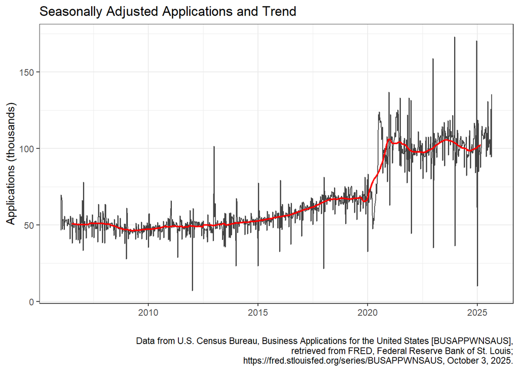

```r
ggplot(decomp, aes(date, season_adjust)) +
  geom_line(color = "#444") +
  geom_line(aes(y = trend), color = "red", size = 0.8) +
  this_theme +
  labs(
    title = "Seasonally Adjusted Applications and Trend",
    y = "Applications (thousands)"
  )
```

# Conclusion

By separating out regular holiday effects, we see a clear rise in new business applications after 2020 that persists over time. Seasonal adjustment makes the week-to-week story easier to read, while the trend line highlights the longer-run shift.